# Differential Gene Expression Analysis

Alexander Ham

2023-04-24

Loaded in size factor normalized DESeq object generated from “FeatureCounts Changes.rmd”

```r
setwd("C:/Users/hamal/OneDrive/Documents/ANGSD/Project")
deseq.ds <- readRDS("deseq.ds.rds")
```

```r
#reorder conditions to LFD, HFD
deseq.ds$condition %<>% relevel(ref="LFD")
```

I generated dispersion estimates and Wald statistics for the DESeq object. Size factor normalization was already done previously.

```r
deseq.ds %<>% estimateDispersions()
deseq.ds %<>% nbinomWaldTest()
```

I generated the differential gene expression results based on FDR correction with independent filtering and an adjusted significance level of 0.05

```r
dge.results <- results(deseq.ds, independentFiltering = TRUE, alpha = 0.05)
summary(dge.results)
```

```
##
## out of 22531 with nonzero total read count
## adjusted p-value < 0.05
## LFC > 0 (up)       : 1872, 8.3%
## LFC < 0 (down)     : 1732, 7.7%
## outliers [1]       : 1, 0.0044%
## low counts [2]     : 7863, 35%
## (mean count < 3)
## [1] see 'cooksCutoff' argument of ?results
## [2] see 'independentFiltering' argument of ?results
```

There are 3604 differentially expressed genes between conditions

```r
table(dge.results$padj < 0.05)
```

```
##
## FALSE  TRUE
## 11063  3604
```

The MA plot shows that there is a fairly even distribution between positive and negative fold changes. We also see that we filtered out many genes with high fold changes but low mean counts.

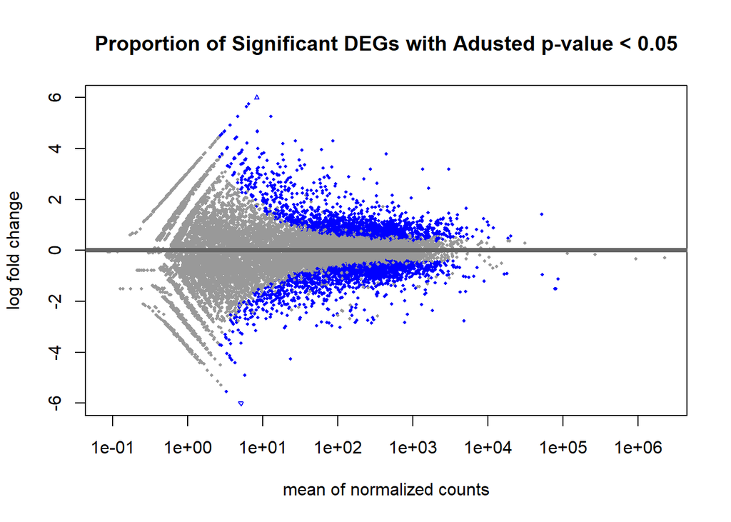

```r
plotMA(dge.results, alpha=0.05, main="Proportion of Significant DEGs with Adusted p-value < 0.05", ylim = c(-6,6))
```

The volcano plot also demonstrates an even distribution of upregulated and downregulated genes, with a collection of high FC, low p-value genes in either group.

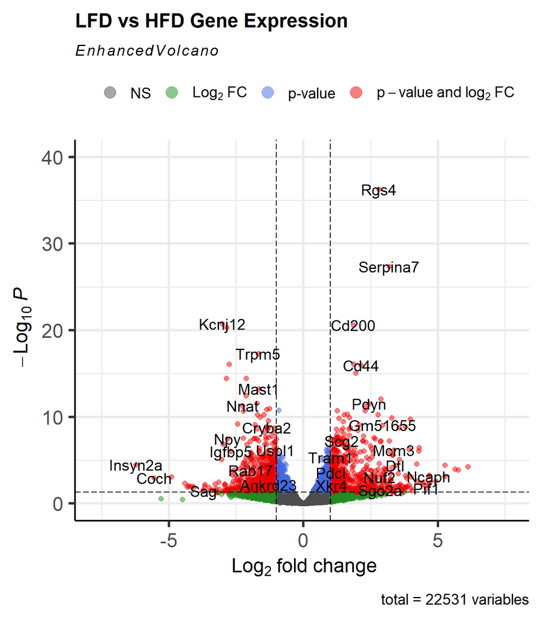

```r
EnhancedVolcano(dge.results, lab=rownames(dge.results), x='log2FoldChange', y='padj',
                pCutoff=0.05, title="LFD vs HFD Gene Expression", ylim = c(0,40))
```

Next I examine GO term enrichment to get an overview of transcriptional differences between conditions.

```r
#create vector of DE genes
dge.genes <- rownames(subset(dge.results, padj < 0.05))

#construct named vector of 0 (not DE) and 1 (DE)
gene.vector <- row.names(dge.results) %in% dge.genes %>% as.integer
names(gene.vector) <- row.names(dge.results)
```

I used the TxDb.Mmusculus.UCSC.mm39.refGene package for gene annotations. I had to first convert the gene IDs from gene symbols into Entrez IDs, since that is what the UCSC annotations use.

```
## Can't find mm39/refGene length data in genLenDataBase...
```

```
## Found the annotation package, TxDb.Mmusculus.UCSC.mm39.refGene
```

```
## Trying to get the gene lengths from it.
```

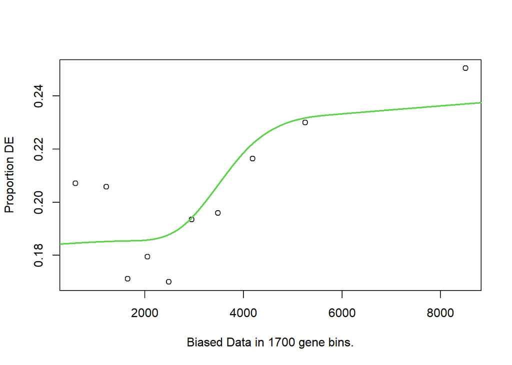

```r
#convert DEG vector from gene symbols to Entrez Ids
names(gene.vector) <- mapIds(org.Mm.eg.db, keys=names(gene.vector), keytype="SYMBOL", column="ENTREZID")
#remove values with missing names
gene.vector <- gene.vector[!is.na(names(gene.vector))]

#calculate probability weighting function for use in GO analysis
pwf <- nullp(gene.vector, "mm39", "refGene")
```

```r
#generate GO term enrichment
go.results <- goseq(pwf, "mm39", "refGene")
```

```
## Fetching GO annotations...
```

```
## For 4082 genes, we could not find any categories. These genes will be excluded.
```

```
## To force their use, please run with use_genes_without_cat=TRUE (see documentation).
```

```
## This was the default behavior for version 1.15.1 and earlier.
```

```
## Calculating the p-values...
```

```r
head(go.results)
```

```
##         category over_represented_pvalue under_represented_pvalue numDEInCat
## 2670  GO:0005737            2.243779e-37                        1       2380
## 2617  GO:0005622            5.362918e-35                        1       2797
## 18255 GO:0110165            2.795537e-31                        1       3154
## 10902 GO:0043226            5.839149e-30                        1       2585
## 10905 GO:0043229            1.654589e-28                        1       2532
## 10903 GO:0043227            9.612011e-27                        1       2421
##       numInCat                               term ontology
## 2670     10006                          cytoplasm       CC
## 2617     12242 intracellular anatomical structure       CC
## 18255    14360         cellular anatomical entity       CC
## 10902    11223                          organelle       CC
## 10905    10986            intracellular organelle       CC
## 10903    10476         membrane-bounded organelle       CC
```

I generated a list of GO biological processes with over_represented_pvalue < 0.001 for visualization in in REVIGO. I am interested in biological processes since I want to observe whether HFD is associated with dysfunctional beta-cells.

```r
sig.GOs.BP <- subset(go.results, over_represented_pvalue < 0.001 & ontology == "BP")
sig.BP.list <- sig.GOs.BP[,1]
sig.BP.scores <- setNames(-log10(sig.GOs.BP$over_represented_pvalue), sig.BP.list)
```

```r
#generate similarity matrix for GO terms
simMatrix <- calculateSimMatrix(sig.BP.list, orgdb = "org.Mm.eg.db", ont = "BP", method="Rel")
```

```
## preparing gene to GO mapping data...
```

```
## preparing IC data...
```

```r
#reduce terms based on similarity
reducedTerms <- reduceSimMatrix(simMatrix, sig.BP.scores, threshold=0.7, orgdb="org.Mm.eg.db")
```

The tree map of differentially expressed biological processes seem indicative of hyperglycemic stress that beta cells experience from HFD. The greatest changes are seen in protein localization, which in the context of beta-cells probably has to do with insulin localization and secretion. There also seem to be major changes in cell division, as seen by the categories mitotic sister chromatid segregation, cell cycle, and cell division. There also seem to be major differences in metabolism between the two conditions.

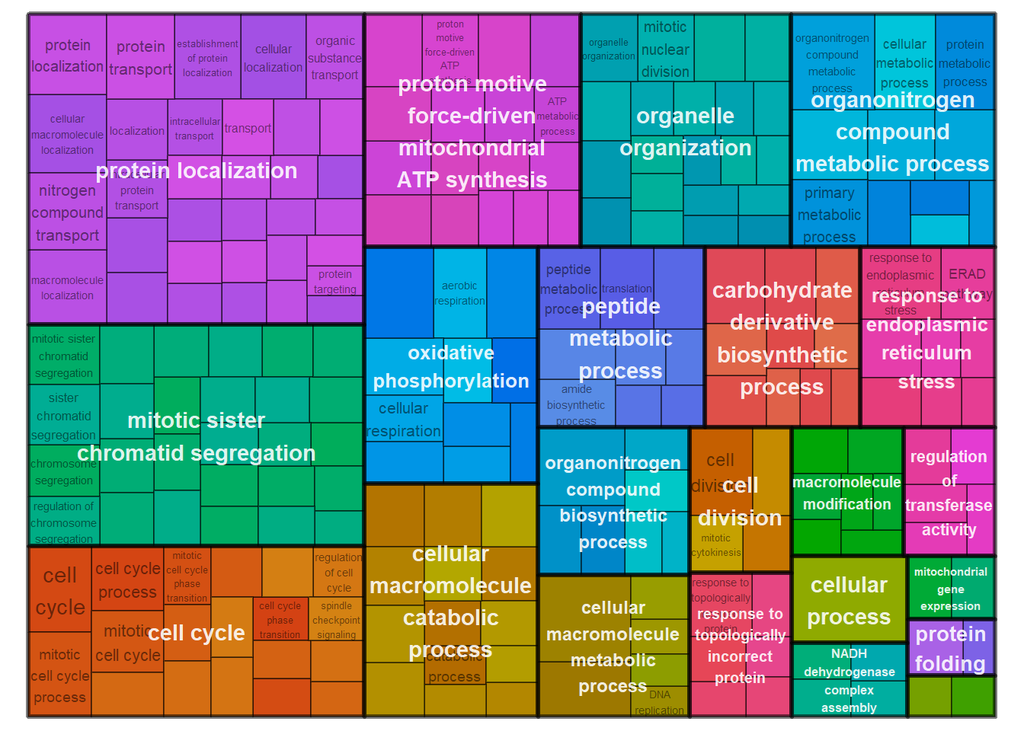

```r
treemapPlot(reducedTerms)
```

Next I examine the hypothesis that HFD beta-cells have reduced expression of beta-cell identity markers.

While it is functional protein that likely is expressed downstream of other essential beta-cell transcription factors, I examine insulin expression under each condition. I expect reduced expression of insulin under HFD, since these mice are hyperglycemic, indicating a degree of beta-cell dysfunction. The results indicate that both Ins2 and Ins1 are reduced under HFD, but are not statistically significant.

```r
Ins2_results <- dge.results["Ins2",]
print(Ins2_results)
```

```
## log2 fold change (MLE): condition HFD vs LFD
## Wald test p-value: condition HFD vs LFD
## DataFrame with 1 row and 6 columns
##       baseMean log2FoldChange     lfcSE      stat    pvalue      padj
##      <numeric>      <numeric> <numeric> <numeric> <numeric> <numeric>
## Ins2   2260546      -0.292404  0.153622   -1.9034 0.0569889  0.151781
```

```r
Ins1_results <- dge.results["Ins1",]
print(Ins1_results)
```

```
## log2 fold change (MLE): condition HFD vs LFD
## Wald test p-value: condition HFD vs LFD
## DataFrame with 1 row and 6 columns
##       baseMean log2FoldChange     lfcSE      stat    pvalue      padj
##      <numeric>      <numeric> <numeric> <numeric> <numeric> <numeric>
## Ins1    929913      -0.331708  0.199349  -1.66396 0.0961209  0.220834
```

To test whether loss of beta-cell identity occurs under HFD, I assembled a list of beta-cell identity markers from [Swisa 2017, Metabolic Stress and Compromised Identity of Pancreatic Beta Cells]. This list is comprised of the transcription factors Pdx1, MafA, NeuroD1, Nkx6.1, FoxO1, Pax6, and Nkx2.2. The results indicate that that only Nkx6.1 and MafA have statistically significant differences, where MafA is downregulated and Nkx6.1 is upregulated in HFD mice.

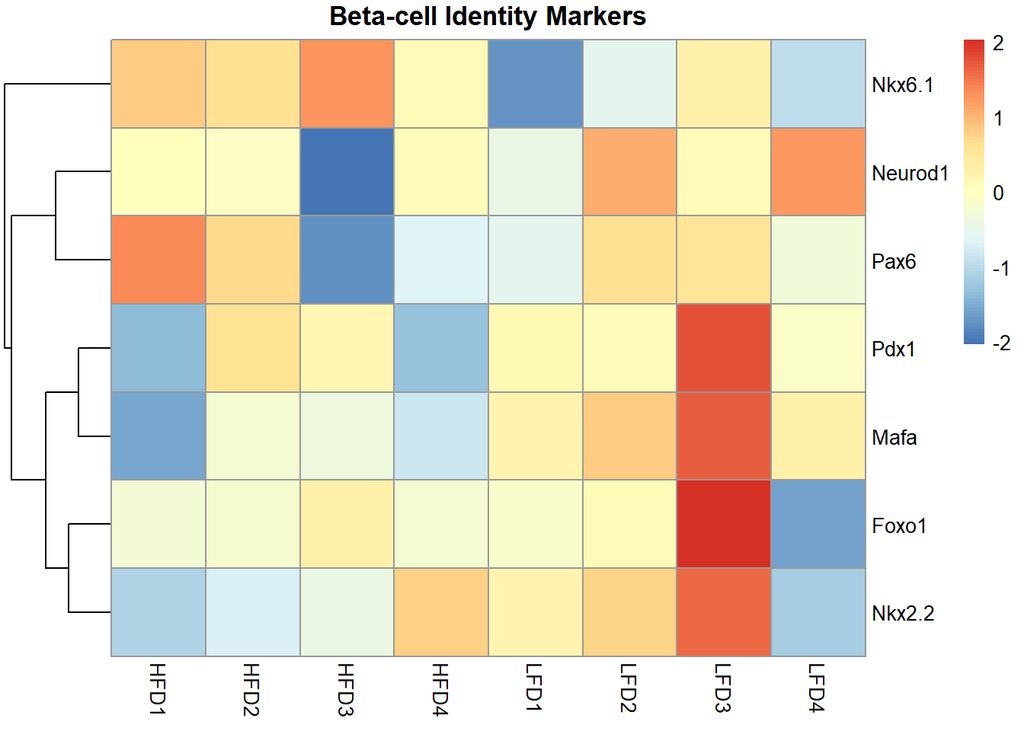

```r
beta.identity.genes <- c("Pdx1", "Mafa", "Neurod1", "Nkx6.1", "Foxo1", "Pax6", "Nkx2.2")

#rlog normalize the counts data
deseq.counts <- counts(deseq.ds)
deseq.counts.rlg <- rlog(deseq.counts, blind=FALSE)
#get rlog normalized counts data for beta-cell identity genes
beta.identity.rlg <- deseq.counts.rlg[beta.identity.genes,]
#create heatmap
pheatmap(beta.identity.rlg, scale = "row", main = "Beta-cell Identity Markers", cluster_cols = FALSE)
```

```r
#DESeq results of beta-cell identity genes
results.beta.identity <- subset(dge.results, rownames(dge.results) %in% beta.identity.genes) %>%   as.data.frame()

results.beta.identity
```

```
##          baseMean log2FoldChange     lfcSE       stat       pvalue         padj
## Neurod1 1052.1091    -0.18174621 0.1537345 -1.1822086 2.371229e-01 0.4067778113
## Pax6    1881.9442    -0.01925502 0.1507740 -0.1277079 8.983802e-01 0.9438783660
## Nkx2.2  1150.6686    -0.14570726 0.1616459 -0.9013980 3.673768e-01 0.5467040207
## Foxo1    346.9523    -0.05560985 0.1781028 -0.3122346 7.548622e-01 0.8573303519
## Nkx6.1  1073.1150     0.47067710 0.1755582  2.6810324 7.339540e-03 0.0346243422
## Pdx1    1525.2548    -0.24422423 0.1802389 -1.3550026 1.754167e-01 0.3318933559
## Mafa    5019.5746    -1.04188455 0.2455425 -4.2431944 2.203604e-05 0.0004838363
```

Next I examined endocrine progenitor cell markers to test for beta-cell dedifferentiation. Markers for endocrine progenitor cells were identified from [Dassaye 2016, Transcription factor regulation of pancreatic organogenesis, differentiation and maturation]. There does not appear to be any major difference in expression of these markers between groups.

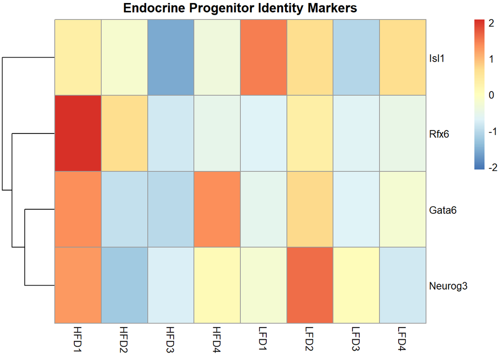

```r
prog.identity.genes <- c("Isl1", "Rfx6", "Gata6", "Neurog3")
#get rlog normalized counts data for progenitor identity genes
prog.identity.rlg <- deseq.counts.rlg[prog.identity.genes,]
#create heatmap
pheatmap(prog.identity.rlg, scale = "row", main = "Endocrine Progenitor Identity Markers", cluster_cols = FALSE)
```

```r
#DESeq results of progenitor identity genes
results.prog.identity <- subset(dge.results, rownames(dge.results) %in% prog.identity.genes) %>% as.data.frame()

results.prog.identity
```

```
##          baseMean log2FoldChange     lfcSE       stat    pvalue      padj
## Rfx6    725.92265      0.3342429 0.2329528  1.4348095 0.1513414 0.3002062
## Neurog3  16.39472     -0.3055239 0.6632697 -0.4606330 0.6450619 0.7805450
## Isl1    809.14045     -0.2392130 0.1833850 -1.3044309 0.1920867 0.3541076
## Gata6    18.49826      0.1590305 0.4214320  0.3773574 0.7059080 0.8253789
```

Finally I examine alpha-cell identity markers to test for transdifferentiation between beta-cells and alpha-cells. Markers for alpha cells were identified from [Dassaye 2016, Transcription factor regulation of pancreatic organogenesis, differentiation and maturation]. There is no difference in expression of the alpha-cell transcription factors Arx and MafB. However, Glucagon is significantly upregulated in LFD beta-cells.

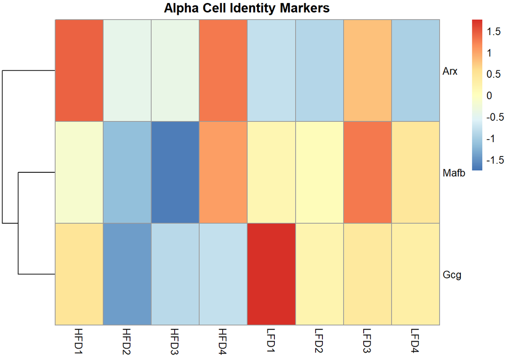

```r
alpha.identity.genes <- c("Arx", "Mafb", "Gcg")
#get rlog normalized counts data for progenitor identity genes
alpha.identity.rlg <- deseq.counts.rlg[alpha.identity.genes,]
#create heatmap
pheatmap(alpha.identity.rlg, scale = "row", main = "Alpha Cell Identity Markers", cluster_cols = FALSE)
```

```r
#DESeq results of progenitor identity genes
results.alpha.identity <- subset(dge.results, rownames(dge.results) %in% alpha.identity.genes) %>% as.data.frame()

results.alpha.identity
```

```
##         baseMean log2FoldChange     lfcSE       stat      pvalue       padj
## Gcg  1835.680530     -0.8188912 0.2684274 -3.0506994 0.002283091 0.01479116
## Mafb   34.075590     -0.5799657 0.4147536 -1.3983379 0.162011609 0.31402462
## Arx     1.152906      1.4628080 1.7048157  0.8580446 0.390867814         NA
```